# Lab assignment 1: t-tests, linear regression, analyzing lexical decision task

INFOMEPL

Deadline: Tuesday, February 27

```r
library(dplyr)
```

```r
library(ggplot2)
itemdata <- read.csv("MALD1_SelectedItemData.csv", sep="\t")
responsedata <- read.csv("MALD1_SelectedResponseData.csv", sep="\t")
```

### Q1: Merge data and report basic information

Merge the two data frames (responsedata and itemdata) into one data frame. Afterwards, report descriptive summaries for the whole dataset and also separately for Subjects 15351, 16854 and 170373. Report summaries of the following measures:

1. Reaction times (RT)
2. Frequencies (use FreqCOCAspok, which is a spoken corpus of American English).
3. RT for words and pseudowords separately. Use the variable IsWord: when it is TRUE, the word is a real word, when it is FALSE it is a pseudoword.

For descriptive summaries it is enough you report means and spread of data - e.g., variances or standard deviations, or just a range of data. You can also provide histograms (for example, by replicating the code we have above; for RTs this is already done).

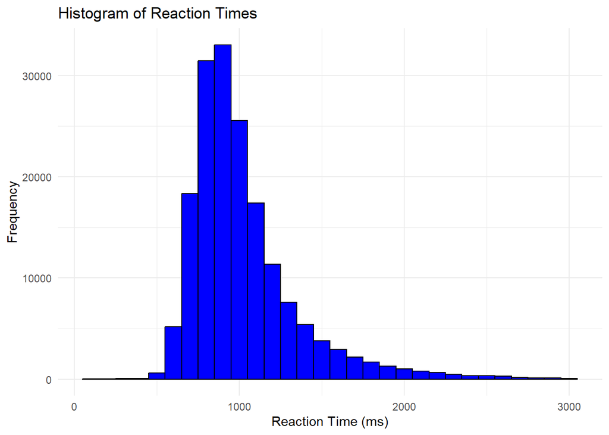

```r
# Merge data frames by item column which belongs to both data frames
merged_data <- merge(responsedata, itemdata, by = "Item")


# Overall descriptive summaries using range function to only get 1 row per summaries group
overall_summaries <- merged_data %>%
  summarise(
    MeanRT = mean(RT, na.rm = TRUE),
    SdRT = sd(RT, na.rm = TRUE),
    MinRT = min(RT, na.rm = TRUE),
    MaxRT = max(RT, na.rm = TRUE),
    MeanFreqCOCAspok = mean(FreqCOCAspok, na.rm = TRUE),
    SdFreqCOCAspok = sd(FreqCOCAspok, na.rm = TRUE),
    MinFreqCOCAspok = min(FreqCOCAspok, na.rm = TRUE),
    MaxFreqCOCAspok = max(FreqCOCAspok, na.rm = TRUE)
  )

# RT for words and pseudowords
word_pseudoword_summary <- merged_data %>%
  group_by(IsWord) %>%
  summarise(
    MeanRT = mean(RT, na.rm = TRUE),
    SdRT = sd(RT, na.rm = TRUE),
    MinRT = min(RT, na.rm = TRUE),
    MaxRT = max(RT, na.rm = TRUE)
  )

# For specific subjects
subjects_summary <- merged_data %>%
  filter(Subject %in% c(15351, 16854, 170373)) %>%
  group_by(Subject) %>%
  summarise(
    MeanRT = mean(RT, na.rm = TRUE),
    SdRT = sd(RT, na.rm = TRUE),
    MinRT = min(RT, na.rm = TRUE),
    MaxRT = max(RT, na.rm = TRUE),
    MeanFreqCOCAspok = mean(FreqCOCAspok, na.rm = TRUE),
    SdFreqCOCAspok = sd(FreqCOCAspok, na.rm = TRUE),
    MinFreqCOCAspok = min(FreqCOCAspok, na.rm = TRUE),
    MaxFreqCOCAspok = max(FreqCOCAspok, na.rm = TRUE)
  )

# View the data frames
View(overall_summaries)
View(subjects_summary)
View(word_pseudoword_summary)

# Histogram for Response times (overall)
ggplot(merged_data, aes(x = RT)) +
  geom_histogram(binwidth = 100, fill = "blue", color = "black") +
  labs(title = "Histogram of Reaction Times", x = "Reaction Time (ms)", y = "Frequency") +
  theme_minimal()
```

### Q2: Implement Cohen’s d and the calculation of t values

In answering this question, you are not allowed to use any R packages or R functions that implement Cohen’s d or the calculation of t-tests. However, you can use such packages (for example, effsize for Cohen’s d and t.test for t-values) to double-check that your function works correctly. In doing so, be careful - some implementations might slightly differ wrt how they calculate $s$, so you might not get exactly identical numbers. This is another reason why you should not just rely on another package in your answer. If you check, say, stackoverflow or use an AI tool like ChatGPT, you should also be careful – there are various ways of implementing Cohen’s $d$ and $t$ calculation and not all are equivalent to what we do here.

First, implement Cohen’s $d$ as a function in R. That is, you have to fill in the body of the function (what is put in as…) that you have here below. As said above, it is enough to implement the simplified version (one in which the length of $x_1$ and $x_2$ is the same).

```r
# n1 and n2 should be equal
cohend <- function(x1, x2) {
  mean_x1 <- mean(x1)
  mean_x2 <- mean(x2)
  s <- sqrt((length(x1) - 1) * (var(x1) + var(x2)) / (2*length(x1) - 2))
  d <- (mean_x1 - mean_x2) / s
  return(d)
}
```

1. RTs for words and pseudowords for Subject numbered 15351.
2. RTs for words and pseudowords for Subject numbered 16854.
3. RTs for words and pseudowords for Subject numbered 170373.
4. RTs for all words and pseudowords.
5. RTs for the two vectors provided below as word_15292 and pseudoword_15292 (these are a few selected responses to words and pseudowords from subject 15292).

```r
subject_number <- 15351

# Get the response time for the word and pseudowords
words_rt <- merged_data %>%
  filter(Subject == subject_number, IsWord == TRUE) %>%
  pull(RT)

pseudowords_rt <- merged_data %>%
  filter(Subject == subject_number, IsWord == FALSE) %>%
  pull(RT)

effect_size_classification <- function(d) {
  if(abs(d) < 0.5) {
    return("small")
  } else if(abs(d) < 0.8) {
    return("medium")
  } else {
    return("large")
  }
}


# 1.Calculate Cohen's d for 15351
# "Cohen's d for subject 15351 is -1.39943111730686 . Effect size is large ."
subject_number <- 15351

words_rt <- merged_data %>%
  filter(Subject == subject_number, IsWord == TRUE) %>%
  pull(RT)

pseudowords_rt <- merged_data %>%
  filter(Subject == subject_number, IsWord == FALSE) %>%
  pull(RT)

d_value <- cohend(words_rt, pseudowords_rt)
effect_size <- effect_size_classification(d_value)

print(paste("Cohen's d for subject", subject_number, "is", d_value, ". Effect size is", effect_size, "."))
```

```
## [1] "Cohen's d for subject 15351 is -1.39943111730686 . Effect size is large ."
```

```r
# 2.Calculate Cohen's d for 16854
#  "Cohen's d for subject 16854 is -0.171013812364667 . Effect size is small ."
subject_number <- 16854

words_rt <- merged_data %>%
  filter(Subject == subject_number, IsWord == TRUE) %>%
  pull(RT)

pseudowords_rt <- merged_data %>%
  filter(Subject == subject_number, IsWord == FALSE) %>%
  pull(RT)

d_value <- cohend(words_rt, pseudowords_rt)
effect_size <- effect_size_classification(d_value)

print(paste("Cohen's d for subject", subject_number, "is", d_value, ". Effect size is", effect_size, "."))
```

```
## [1] "Cohen's d for subject 16854 is -0.171013812364667 . Effect size is small ."
```

```r
# 3. Calculate Cohen's d for 170373
# "Cohen's d for subject 170373 is -0.343143399184897 . Effect size is small ."

subject_number <- 170373

words_rt <- merged_data %>%
  filter(Subject == subject_number, IsWord == TRUE) %>%
  pull(RT)

pseudowords_rt <- merged_data %>%
  filter(Subject == subject_number, IsWord == FALSE) %>%
  pull(RT)

d_value <- cohend(words_rt, pseudowords_rt)
effect_size <- effect_size_classification(d_value)

print(paste("Cohen's d for subject", subject_number, "is", d_value, ". Effect size is", effect_size, "."))
```

```
## [1] "Cohen's d for subject 170373 is -0.343143399184897 . Effect size is small ."
```

```r
# 4.For all words and pseudowords
# "Cohen's d for all words and pseudowords 170373 is -0.410810089564915 . Effect size is small ."
words_rt <- merged_data %>%
  filter(IsWord == TRUE) %>%
  pull(RT)

pseudowords_rt <- merged_data %>%
  filter( IsWord == FALSE) %>%
  pull(RT)

d_value <- cohend(words_rt, pseudowords_rt)
effect_size <- effect_size_classification(d_value)

print(paste("Cohen's d for all words and pseudowords", subject_number, "is", d_value, ". Effect size is", effect_size, "."))
```

```
## [1] "Cohen's d for all words and pseudowords 170373 is -0.410810089564973 . Effect size is small ."
```

```r
# 5.Calculate Cohen's d for the 2 vectors

subject_number <- 15292
#  "Cohen's d for subject 15292 is 0 . Effect size is small ."
word_15292 <- c(2206, 1583, 1154, 1010,  865,  931, 1129,  683,  820, 1132, 1049, 1211, 1261, 957, 1058,  790,  851, 1908, 1504, 1400,  924)

pseudoword_15292 <- c(677,  949,  889,  881,  917,  769,  772,  922, 1944,  881,  976, 1087, 1252,  914, 1277,  825, 1295, 1336,  788,  885,  932)
d_value <- cohend(word_15292, word_15292)
effect_size <- effect_size_classification(d_value)

print(paste("Cohen's d for subject", subject_number, "is", d_value, ". Effect size is", effect_size, "."))
```

```
## [1] "Cohen's d for subject 15292 is 0 . Effect size is small ."
```

Finally, implement the t-calculation as a function. That is, fill in the body of this function (the same limitation that applied to Cohen’s d applies here – you cannot use other packages or R functions like t.test but you can consult AI tools or websites - and again, be careful if you use that, because there are different versions of t-tests):

```r
tcalculation <- function(x1, x2) {
  mean_x1 <- mean(x1)
  mean_x2 <- mean(x2)
  se <- sqrt((var(x1) + var(x2)) / length(x1))
  t <- (mean_x1 - mean_x2) / se

}

subject_number <- 15351

words_rt <- merged_data %>%
  filter(Subject == subject_number, IsWord == TRUE) %>%
  pull(RT)

pseudowords_rt <- merged_data %>%
  filter(Subject == subject_number, IsWord == FALSE) %>%
  pull(RT)

t_value <- tcalculation(words_rt, pseudowords_rt)

print(paste("1: T value d for subject", subject_number, "is", t_value, "."))
```

```
## [1] "1: T value d for subject 15351 is -19.5419920467928 ."
```

```r
# T value for all words
words_rt <- merged_data %>%
  filter(IsWord == TRUE) %>%
  pull(RT)

pseudowords_rt <- merged_data %>%
  filter( IsWord == FALSE) %>%
  pull(RT)

t_value <- tcalculation(words_rt, pseudowords_rt)

print(paste("2: T value d for all words is", t_value, "."))
```

```
## [1] "2: T value d for all words is -85.2814437314518 ."
```

```r
# T value for specified vectors
word_15292 <- c(2206, 1583, 1154, 1010,  865,  931, 1129,  683,  820, 1132, 1049, 1211, 1261, 957, 1058,  790,  851, 1908, 1504, 1400,  924)

pseudoword_15292 <- c(677,  949,  889,  881,  917,  769,  772,  922, 1944,  881,  976, 1087, 1252,  914, 1277,  825, 1295, 1336,  788,  885,  932)

t_value <- tcalculation(word_15292, pseudoword_15292)

print(paste("3: T value d for specified vectors is", t_value, "."))
```

```
## [1] "3: T value d for specified vectors is 1.50136643517682 ."
```

```r
print(t.test(word_15292, pseudoword_15292,  paired = FALSE, alternative = "two.sided"))
```

```
##
##  Welch Two Sample t-test
##
## data:  word_15292 and pseudoword_15292
## t = 1.5014, df = 37.008, p-value = 0.1417
## alternative hypothesis: true difference in means is not equal to 0
## 95 percent confidence interval:
##  -54.23106 364.51678
## sample estimates:
## mean of x mean of y
##  1163.143  1008.000
```

Once the implementation is done, calculate $t$ for:

1. RTs for words and pseudowords for Subject numbered 15351.
2. RTs for all words and pseudowords.
3. RTs for the two vectors provided below as word_15292 and pseudoword_15292 (these are a few selected responses to words and pseudowords from subject 15292).

Report the t-values and say briefly why RTs for all words and pseudowords (the second question above) have the highest t-value compared to pseudoword/word_15292 and compared to the responses of Subject numbered 15351, and why this is not so for Cohen’s d. A brief description of the crucial intuition suffices.

*t-value = measure of the difference between group means relative to the variability within the groups => difference in reaction times between all words and pseudowords is much larger compared to the differences observed for Subject 15351 and for the specified vectors. This makes sense since the size of the grouos is much larger for all words and pseudowords, followed by all values for subject 15351 and by the given vectors, that represent just a small part of the values for words and pseudowords from SUbject 15292.* *cohen’s d = effect size => difference is statistically significant due to the large sample size for all words and pseudowords, but the practical significance is small.*

### Q3: transforming data and collecting p-values

Based on what we said so far, you should be able to tie t-values that you provided in Q2 to p-values under the null hypothesis that population means between RTs of words and RTs for pseudowords do not differ, i.e., mean(wordRT)=mean(pseudowordRT). Use the t-value from Q2 for the data set word_15292 and pseudoword_15292 and use the function *pt* (with degrees of freedom = 40) to provide the answer.

When you are done, come back to one of the assumptions of $t$-probability distributions: t-values are collected from samples of *independent and identically normally distributed data*. We focus on the latter condition. Check if RTs in words and pseudowords are normally distributed.

If not, try a transformation to get closer to normal distribution. Among transformations, it is common to consider squaring, cubing, taking an inverse, taking square root, or log-transforming data. It is fine if you find only a roughly normal distribution (no testing needed, just checking by observing a histogram is sufficient for this exercise).

Once you find the best case of transformation, report t-values and p-values for this transformed distribution. You can decide whether you want to use one-tailed or two-tailed tests but whatever you decide, report that.

```r
t_15292 <- tcalculation(word_15292, pseudoword_15292)
print(t_15292)
```

```
## [1] 1.501366
```

```r
pt(t_15292, df=40)
```

```
## [1] 0.9294429
```

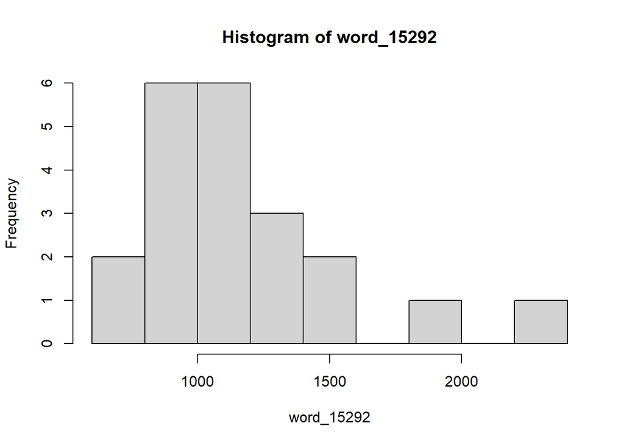

```r
# not normally distributed
hist(word_15292)
```

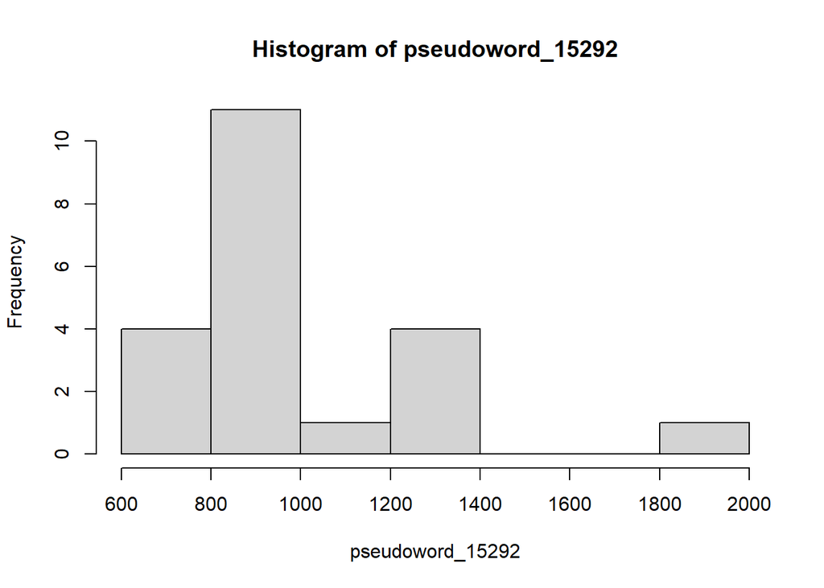

```r
hist(pseudoword_15292)
```

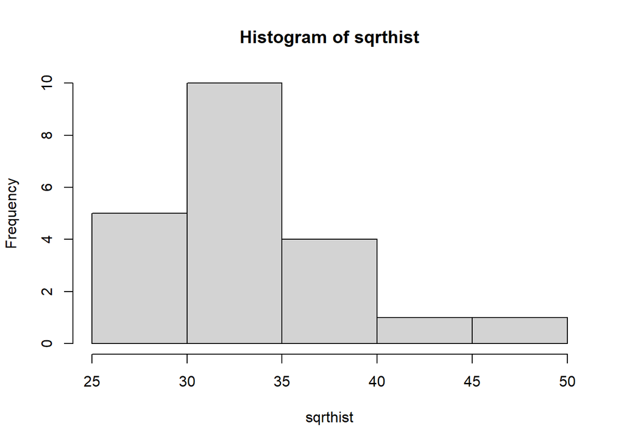

```r
#square the values - not normal
sqrthist <- sqrt(word_15292)
hist(sqrthist)
```

```r
#cube the values - not normal
cuberoot = function(x) {
     if(x < 0)
    { - (-x)^(1/3)}
    else
    {x^(1/3)}
    }
cubelist <- sapply(word_15292, cuberoot)
print(cubelist)
```

```
##  [1] 13.017727 11.654500 10.489029 10.033223  9.528079  9.764497 10.412731
##  [8]  8.806572  9.359902 10.421946 10.160736 10.658957 10.803680  9.854562
## [15] 10.189712  9.244335  9.476396 12.402982 11.457309 11.186889  9.739963
```

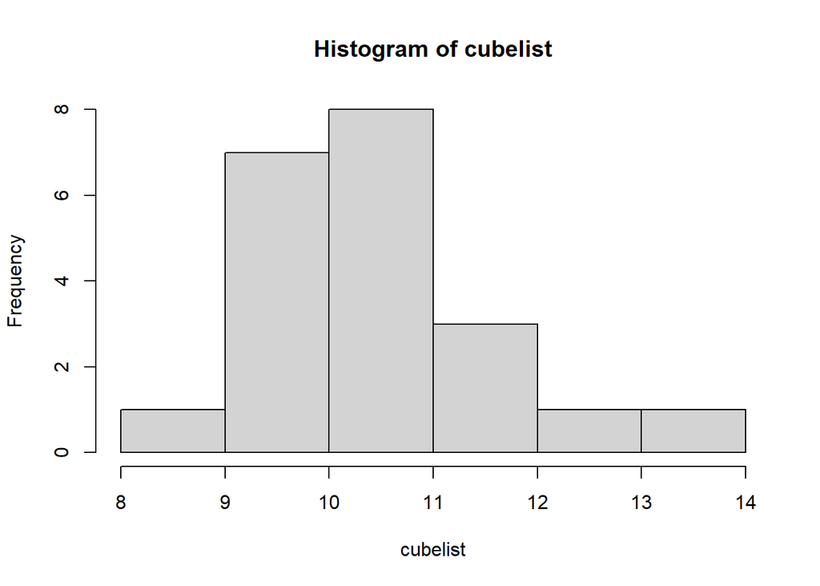

```r
hist(cubelist)
```

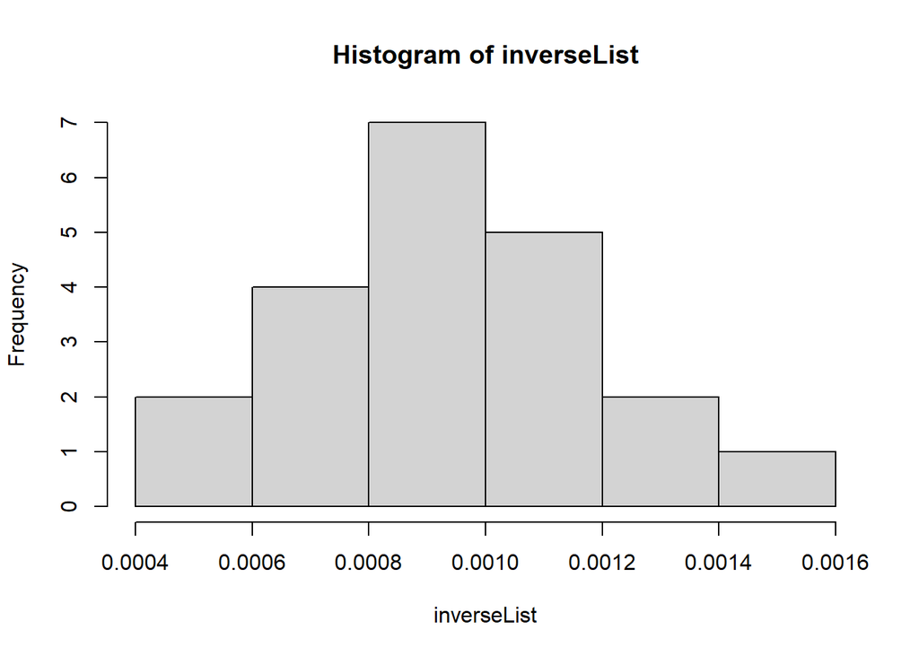

```r
#inverse the values - NORMAL
inverseList  <- sapply(word_15292, function(x) 1/x)
hist(inverseList)

pseudoinverseList  <- sapply(pseudoword_15292, function(x) 1/x)
hist(inverseList)
```

```r
#t and p values one-tailed
inverseT <- tcalculation(inverseList, pseudoinverseList)
print(inverseT)
```

```
## [1] -1.556482
```

```r
pval <- pt(inverseT, df=40, lower.tail = FALSE)
print(paste("T-value of the inversed data (one-tailed)", as.character(inverseT)))
```

```
## [1] "T-value of the inversed data (one-tailed) -1.55648217416487"
```

```r
print(paste("P-value of the inversed data (one-tailed)", as.character(pval)))
```

```
## [1] "P-value of the inversed data (one-tailed) 0.936264440798912"
```